# PoliceShootingAnalysis

alex maccalman

6/22/2020

This analysis was performed by COL Alex MacCalman in support of a submission to the USMA Math Academy Professor Search Committee.

# Police Shooting and Black Lives Matter Protest Analysis

The purpose of this project is to examine recent data on fatal police shootings and Black Lives Matter (BLM) protest data to open a dialog about racial inequility and the contemporary BLM social movement.

## What is the Per Capita Fatal Police Shootings Among Blacks and Non-Blacks?

Fatal police shooting data was downloaded from the data.world platform located [here](https://data.world/data-society/fatal-police-shootings).

First we will download the data and convert it to a tibble data frame type. Then we examine the data.

```r
download.file("https://raw.githubusercontent.com/washingtonpost/data-police-shootings/master/fatal-police-shootings-data.csv", "police.csv")
df <- tibble(read.csv("police.csv"))
dim(df)
```

```
## [1] 5428   14
```

```r
str(df)
```

```
## tibble [5,428 x 14] (S3: tbl_df/tbl/data.frame)
##  $ id                     : int [1:5428] 3 4 5 8 9 11 13 15 16 17 ...
##  $ name                   : chr [1:5428] "Tim Elliot" "Lewis Lee Lembke" "John Paul Quintero" "Matthew Hoffman" ...
##  $ date                   : chr [1:5428] "2015-01-02" "2015-01-02" "2015-01-03" "2015-01-04" ...
##  $ manner_of_death        : chr [1:5428] "shot" "shot" "shot and Tasered" "shot" ...
##  $ armed                  : chr [1:5428] "gun" "gun" "unarmed" "toy weapon" ...
##  $ age                    : int [1:5428] 53 47 23 32 39 18 22 35 34 47 ...
##  $ gender                 : chr [1:5428] "M" "M" "M" "M" ...
##  $ race                   : chr [1:5428] "A" "W" "H" "W" ...
##  $ city                   : chr [1:5428] "Shelton" "Aloha" "Wichita" "San Francisco" ...
##  $ state                  : chr [1:5428] "WA" "OR" "KS" "CA" ...
##  $ signs_of_mental_illness: chr [1:5428] "True" "False" "False" "True" ...
##  $ threat_level           : chr [1:5428] "attack" "attack" "other" "attack" ...
##  $ flee                   : chr [1:5428] "Not fleeing" "Not fleeing" "Not fleeing" "Not fleeing" ...
##  $ body_camera            : chr [1:5428] "False" "False" "False" "False" ...
```

```r
range(df$date)
```

```
## [1] "2015-01-02" "2020-06-22"
```

```r
df <- mutate(df, date = as.Date(date),year = year(date), Race = if_else(race == "B", "Black", "nonBlack")) %>%
        filter(year != 2020, !race =="")
group <- group_by(df, year, Race)
yearlyshootings <- tibble(summarize(group, shootings =n()))
```

Now we visualize our data.

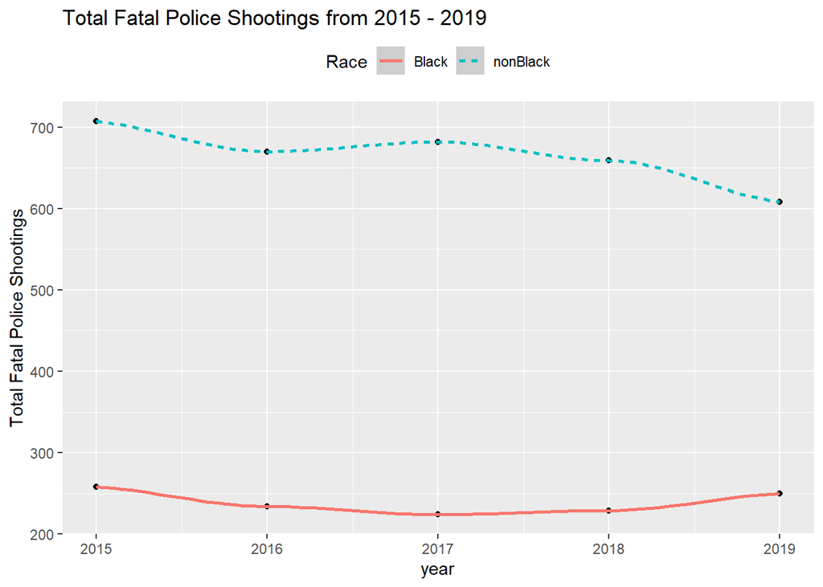

```r
g <- ggplot(yearlyshootings,aes(x = year, y = shootings)) +
        geom_point() +
        geom_smooth(aes(linetype = Race, color = Race)) +
        theme(legend.position = "top") +
        labs(title = "Total Fatal Police Shootings from 2015 - 2019",
             y = "Total Fatal Police Shootings")
suppressWarnings(print(g))
```

The above chart shows the total number of fatal police shootings for blacks and non-black victims. To better understand the relative comparison between these two categories, we now calculate the per capita values. We first need to get data on populations. We acquired the US population data here. This data only went up to 2018 and assume that the 2019 census data equals 2018. The differences between census populations each year is minimal, therefore, we expect that this assumption is valid. Here we read in the data and look at what it looks like.

```r
pop <- read.csv("pop.csv")
head(pop)
```

```
##   year  race       pop
## 1 2015 Black  37923800
## 2 2015 Total 312777900
## 3 2016 Black  38081700
## 4 2016 Total 314466400
## 5 2017 Black  38408000
## 6 2017 Total 317022500
```

The data provides the total US population and black populations. In order to obtain the non-black population, we widen the data table, subtract the black populations from the total, and lengthen back the data table.

```r
pop <- pivot_wider(pop, names_from = race, values_from = pop) %>%
        mutate(nonBlack = Total - Black) %>%
        pivot_longer(cols = c("Black", "nonBlack"), names_to = "race", values_to = "pop")
```

In order to combine both data sets, we first create key values based on the year and race columns and perform an inner join by this key value.

```r
pop <- mutate(pop, key = paste0(year, race))
yearlyshootings <- mutate(yearlyshootings, key = paste0(year, Race))
finaldf <- inner_join(yearlyshootings, pop, by = "key") %>%
        select(year = year.x, race, shootings, pop) %>%
        mutate(perCapita = shootings/pop*100000)
head(finaldf)
```

```
## # A tibble: 6 x 5
##    year race     shootings       pop perCapita
##   <dbl> <chr>        <int>     <int>     <dbl>
## 1  2015 Black          258  37923800     0.680
## 2  2015 nonBlack       707 274854100     0.257
## 3  2016 Black          234  38081700     0.614
## 4  2016 nonBlack       670 276384700     0.242
## 5  2017 Black          224  38408000     0.583
## 6  2017 nonBlack       682 278614500     0.245
```

Next we visualize our data.

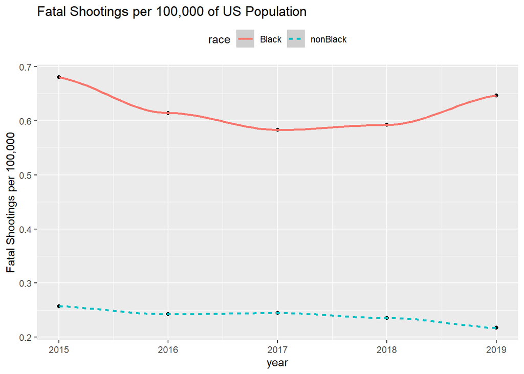

```r
p <- ggplot(finaldf, aes(x = year, y = perCapita)) +
        geom_point() +
        geom_smooth(aes(linetype = race, color = race)) +
        theme(legend.position = "top") +
        labs(title = "Fatal Shootings per 100,000 of US Population", y = "Fatal Shootings per 100,000")
suppressWarnings(print(p))
```

The above chart shows that the black fatal shootings per 1 100,000 is significantly more than non-balck fatal shootings.

## Are Black Poverty Rates Higher Than White Poverty Rates in the US?.

We will now perform a t test to understand if there is a statistical difference between the white and black US poverty rates. We obtained the data from [this website](https://dataverse.harvard.edu/dataset.xhtml?persistentId=doi:10.7910/DVN/L2GSK6), the replication data for the article title “Black Lives Matter: Evidence that Police-Caused Deaths Predict Protest.” The codebook and supporting r scripts are also found here that were developed to write the article. The article can be found here.

Each observation in this data set is for a city designated by a combined state and locality FIPS code. The purpose of the analysis was to gain a better understanding between police violence and protest activity. The primary variable of interest is the total Black Lives Matter (BLM) protests recorded between 8/9/14 and 8/9/15 for each city. The datasets used to create the tidy dataset for the analysis came from the following, categorized by opportunity structures:  
**Resource opportunity structure:**  
1. The 2014 American Community Survey that contains locality-level measures of population, population density, percentage black, and black poverty levels.  
**Political opportunity structure:**  
2. NAACP Activity that contains the history of Black political organizing in an area and serves as an (imperfect) proxy for a tradition of Black political activity. The variable indicates the number of years a locality had a local NAACP branch during this early period of the organization’s activism.  
3. Mayoral Data that contains dummy variables for a black mayor and Republican mayor.  
4. City Level Partisanship. Contains the Democratic vote share of the 2008 presidential election.  
**Education opportunity structure:**  
5. College education. contains the percent of population with a bachelor’s degree or above, the total enrolment of colleges in a locality / total population.  
**Police Caused Deaths**  
6. Data from 1/1/2013-08/09/2014 and 8/10/2014-8/10/2015  
**Crime**  
7. A crime dummy indicator for being listed in the top 100 highest violent crime cities in 2015.

```r
BLM <- tibble(read.csv("BLM_cities.csv"))
```

To perform our comparison we extract the white and black poverty rates, create a new data table and lengthen it to allow us to build a boxplot.

```r
wpoverty <- BLM$WhitePovertyRate
bpoverty <- BLM$BlackPovertyRate
pov <- tibble(white = wpoverty, black = bpoverty)
povlong <- pivot_longer(pov, cols = c("white", "black"), names_to = "race", values_to = "poverty")
head(povlong)
```

```
## # A tibble: 6 x 2
##   race  poverty
##   <chr>   <dbl>
## 1 white     5.4
## 2 black    11.6
## 3 white    12.1
## 4 black    24.5
## 5 white    30.8
## 6 black    38.6
```

Next we visualize the box plot.

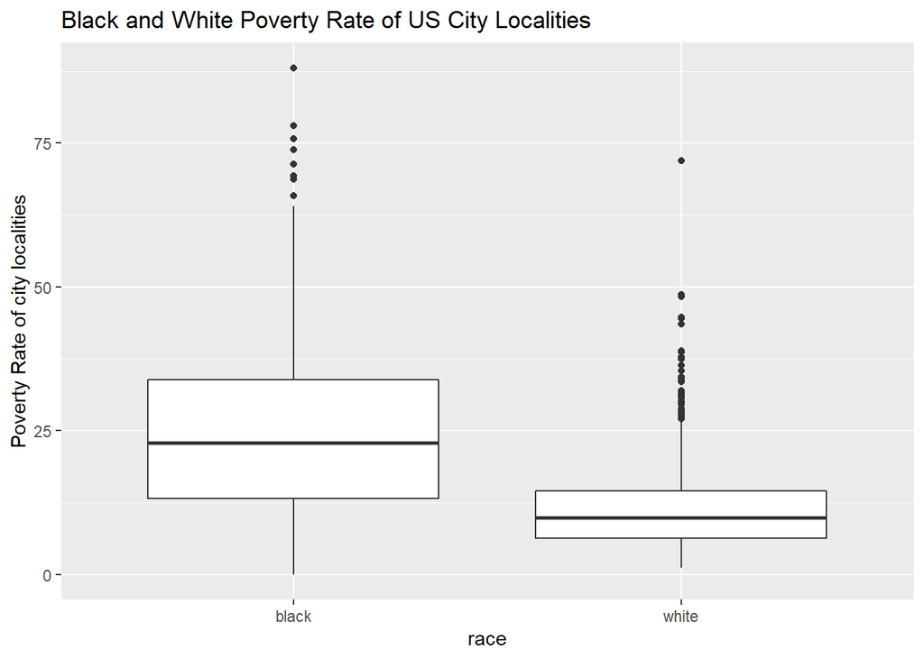

```r
ggplot(povlong, aes(x = race, y = poverty)) +
        geom_boxplot() +
        labs(title = "Black and White Poverty Rate of US City Localities", y= "Poverty Rate of city localities")
```

```r
t.test(pov$black, pov$white)
```

```
##
##  Welch Two Sample t-test
##
## data:  pov$black and pov$white
## t = 30.587, df = 2008.4, p-value < 2.2e-16
## alternative hypothesis: true difference in means is not equal to 0
## 95 percent confidence interval:
##  12.05010 13.70118
## sample estimates:
## mean of x mean of y
##  24.16306  11.28742
```

The p-value is significantly lower than the 0.05 significance level. Therefore, we reject the null hypothesis and conclude that there is a significant difference between the white and black poverty rates. The mean black poverty rate of all US cities is

```r
mean(pov$black)
```

```
## [1] 24.16306
```

while the mean white poverty rate of all US cities is

```r
mean(pov$white)
```

```
## [1] 11.28742
```

## What Variables Explain the Frequency of Black Lives Matter (BLM) Protests?

First we will examine the variables related to the resource, political, and educational opportunity structures. We will examine each variable against the total number of BLM protests. To do this we first write functions for the correlation, a linear plot, a linear regression model fit summary, and the diagnostics plots for the fit.

```r
protests <- BLM$tot.protests
protestCor <- function(x) {
        cor(protests, x)
}
protestPlot <- function(x, title) {
        ggplot(data = BLM, aes(x = x, y = tot.protests)) +
                geom_point() +
                geom_smooth(method = lm) +
                labs(title = title)
}
```

We will start with the resource opportunity structure variable ralated to the black poverty rate.

```r
poverty <- BLM$BlackPovertyRate
protestCor(poverty)
```

```
## [1] 0.108112
```

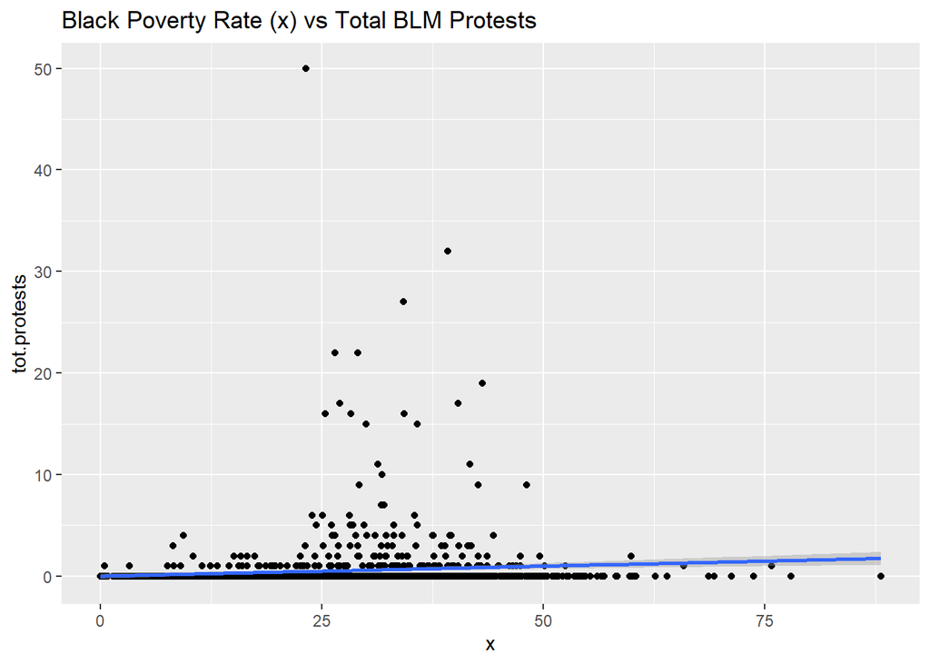

```r
protestPlot(poverty, "Black Poverty Rate (x) vs Total BLM Protests")
```

Although there are data points that have a high number of protests with higher black poverty rates, the data does not show any trend that is of significance as a single variable.

Now we will look at the political opportunity structure.

```r
pol <- BLM$NAACPyears
protestCor(pol)
```

```
## [1] 0.4823707
```

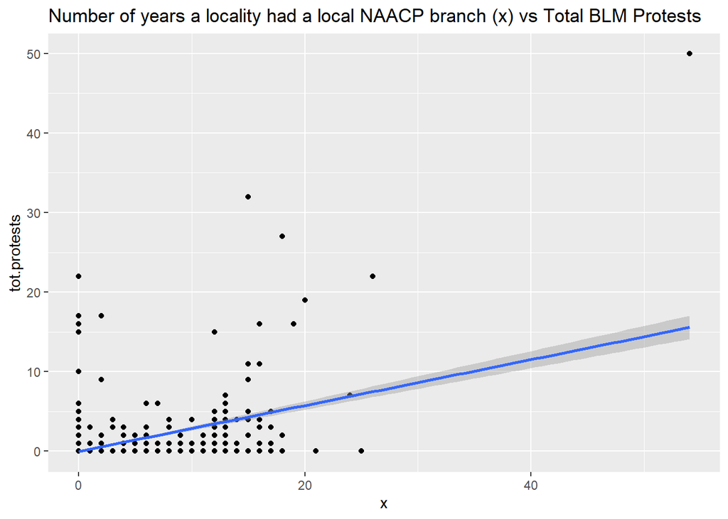

```r
protestPlot(pol, "Number of years a locality had a local NAACP branch (x) vs Total BLM Protests")
```

The NAACP variable is an (imperfect) proxy for a tradition of Black political activity in a city. This variable has a higher correlation and does show a linear trend. Therefore, we now will fit a linear model and check for the diagnostics.

```r
fit <- lm(tot.protests ~ pol, data = BLM)
summary(fit)
```

```
##
## Call:
## lm(formula = tot.protests ~ pol, data = BLM)
##
## Residuals:
##    Min     1Q Median     3Q    Max
## -7.196  0.015  0.015  0.015 34.440
##
## Coefficients:
##             Estimate Std. Error t value Pr(>|t|)
## (Intercept) -0.01489    0.06499  -0.229    0.819
## pol          0.28843    0.01422  20.285   <2e-16 ***
## ---
## Signif. codes:  0 '***' 0.001 '**' 0.01 '*' 0.05 '.' 0.1 ' ' 1
##
## Residual standard error: 2.209 on 1357 degrees of freedom
## Multiple R-squared:  0.2327, Adjusted R-squared:  0.2321
## F-statistic: 411.5 on 1 and 1357 DF,  p-value: < 2.2e-16
```

The coefficient of the NAACP variable x, is statistically significant. However, this single variable only explains 23% of the variation.

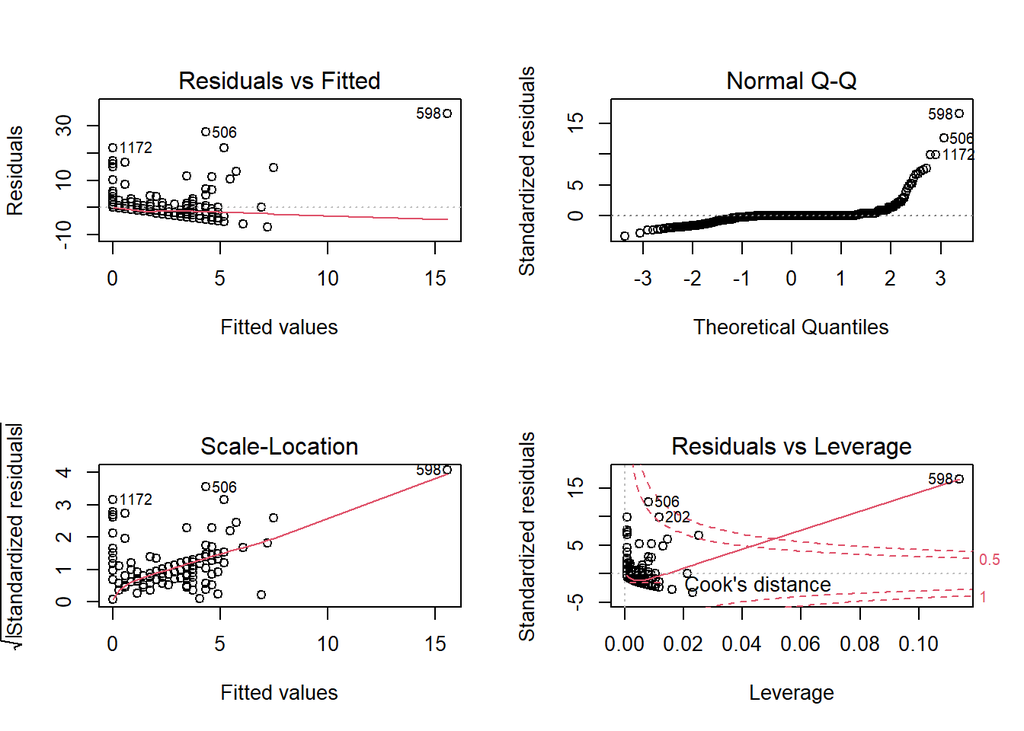

```r
par(mfrow = c(2,2))
plot(fit)
```

The Residuals vs Fitted chart is a scatterplot between the residuals and predicted values and should look random; for this model, they do not. As the fitted values along the x axis increase, the variance of the residuals increases.

The second plot is a normal Q-Q or a normal probability plot. If the errors are distributed normally, we should see a straight lines; for this model we do not.

The third plot should have a relatively straight red line but this model clearly does not.

The last plot calculates the cook’s distance for each point and highlights which point have the highest leverage or influence on the model fit.

These diagnostics indicate that the residual errors do not have equal variance and are not normally distributed. Therefore, we cannot effectively interpret the coefficient of the model fit.

Our last opportunity structure we will examine is the education variable. This variable is the total enrolment of colleges in a locality / total population.

```r
ed <- BLM$collegeenrollpc
protestCor(ed)
```

```
## [1] 0.07240007
```

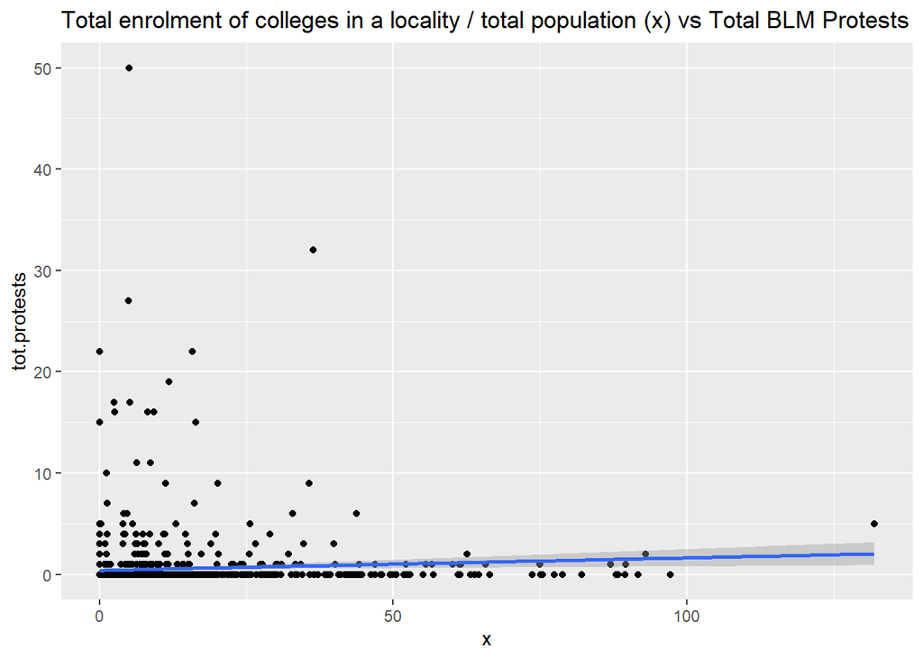

```r
protestPlot(ed, "Total enrolment of colleges in a locality / total population (x) vs Total BLM Protests")
```

Although the plot does not show a trend and the correlation between this education variable and the number of protest is very low, all of the higher values of protest are concentrated on the lower end of the x-axis. This provides some indication that the cities with low enrollment in college have a higher number of protests.

# Conclusion

The analysis of single variable regression among the opportunity structures did not reveal any compelling evidence. The primary reason for this is that the outcome of interest is count data. The total BLM protest can be considered as a rate or frequency. This implies that there are other methods within the generalized linear models methods that could be used to analyze this data. In fact, the author of the article this data supported used a form of Poisson regression modeling call the negative binomial. There are many methods available to analyze data. In this exercise, we learned how to examine data, fit models, and diagnose their fit.